# DAT320: Compulsory assignment 2

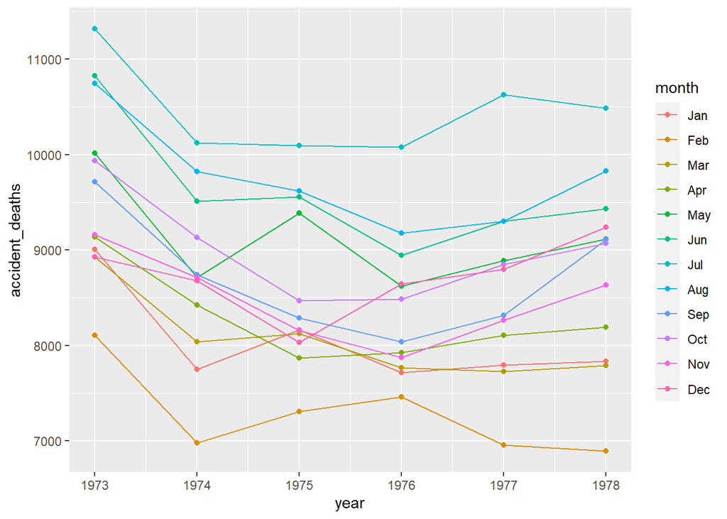

```r
p <- ggplot(plt_death, aes(x =
                             year , y = accident_deaths ,
                           color = as.factor(month))) +
  geom_line() +
  geom_point() +
  scale_color_discrete(labels
                        = month.abb) + labs(color = "month")
p
```

- We see that we don’t have a trend, we have a seasonality within the years, we se that the summer months have the most deaths. we also see that there is no trend not over the years or over the months, but we see in the first plot that the seasonality is higher over the years, within the months.
- We plot the time series, and see what we saw in the earlier plot of the data.

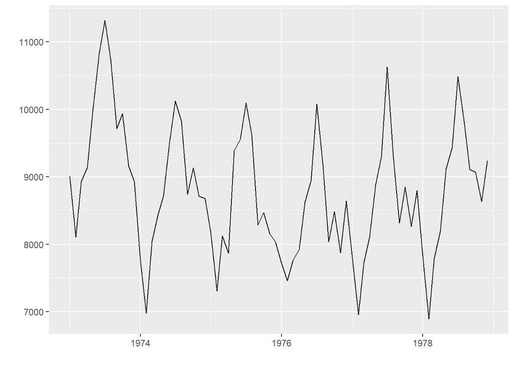

```r
death.ts %>% autoplot()
```

- We see that we have don`t have a trend, but a seasonality.

```r
summary(death.ts)
```

```
##    Min. 1st Qu.  Median    Mean 3rd Qu.    Max.
##    6892    8089    8728    8789    9323   11317
```

- Making a histogram over the data

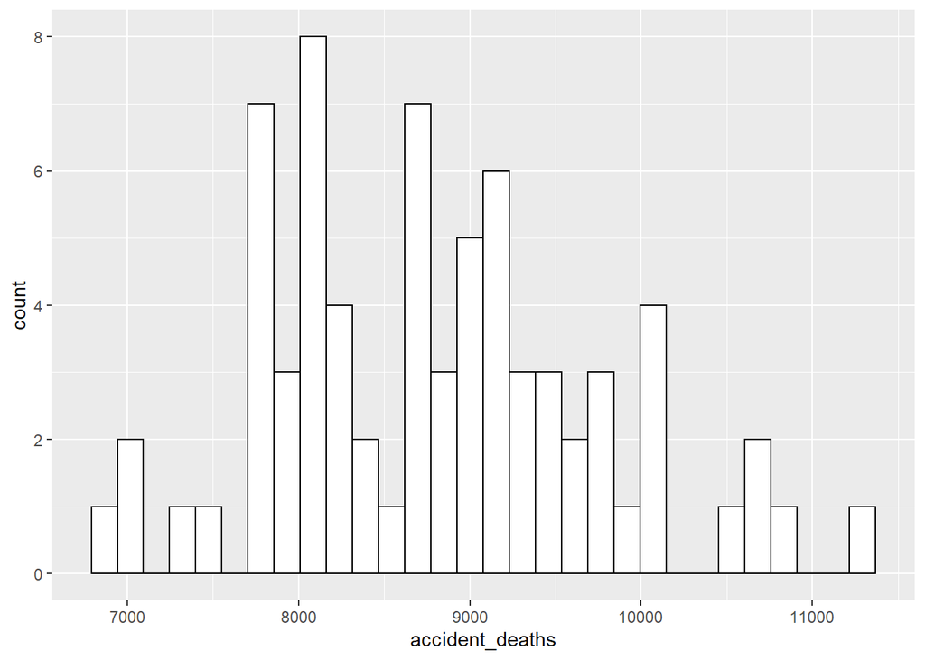

```r
death %>% ggplot(aes(x = accident_deaths)) + geom_histogram(fill = "white", color = "black", bins = 30)
```

- Then we check the stats, her we will also see if we have NA values

```r
statsNA(death.ts)
```

```
## [1] "Length of time series:"
## [1] 72
## [1] "-------------------------"
## [1] "Number of Missing Values:"
## [1] 0
## [1] "-------------------------"
## [1] "Percentage of Missing Values:"
## [1] "0%"
## [1] "-------------------------"
## [1] "Number of Gaps:"
## [1] 0
## [1] "-------------------------"
## [1] "Average Gap Size:"
## [1] 0
## [1] "-------------------------"
## [1] "No NAs in the time series."
## [1] "-------------------------"
```

```
## [1] "There are no NAs in the time series"
```

- We see that we don`t have any missing values.
- Using kpss to check one more time for trends

```r
kpss.test(death.ts)
```

```
##
##  KPSS Test for Level Stationarity
##
## data:  death.ts
## KPSS Level = 0.19799, Truncation lag parameter = 3, p-value = 0.1
```

- we have p-value = 0.1 which is > 0.05 this means we have don`t have a trend. And therefor we don`t use the difference, on the data.
- plot ACF and PACF

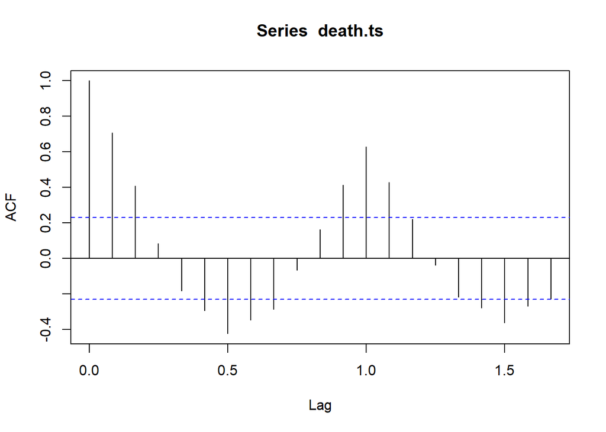

```r
acf_values = acf(death.ts, plot = FALSE, lag.max = 20)
plot(acf_values)
```

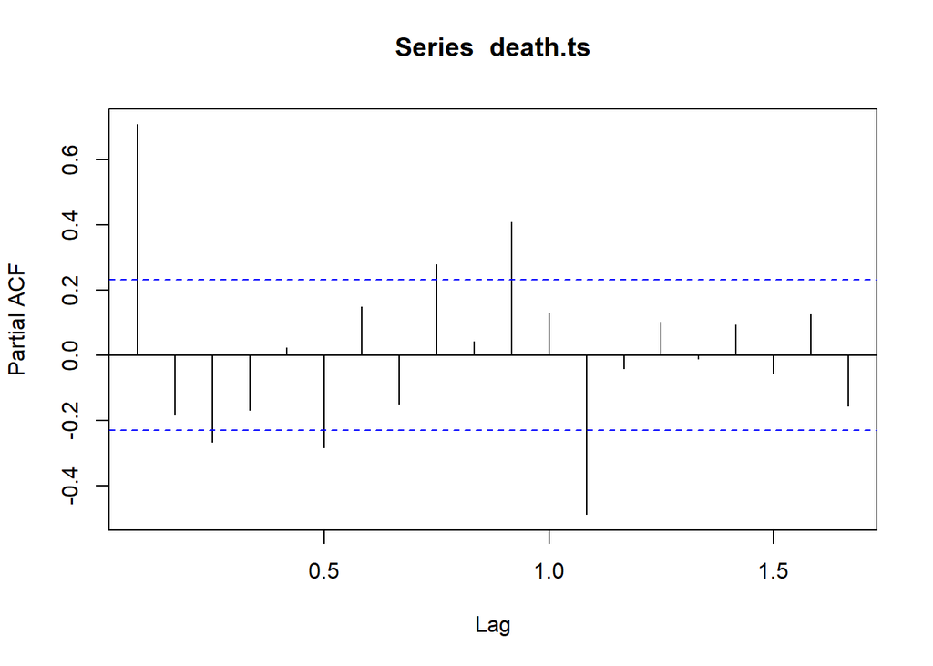

```r
pacf_values = pacf(death.ts, plot = FALSE, lag.max = 20)
plot(pacf_values)
```

```r
mod_arima <- auto.arima(death.ts)
summary(mod_arima)
```

```
## Series: death.ts
## ARIMA(0,1,1)(0,1,1)[12]
##
## Coefficients:
##           ma1     sma1
##       -0.4303  -0.5528
## s.e.   0.1228   0.1784
##
## sigma^2 = 102860:  log likelihood = -425.44
## AIC=856.88   AICc=857.32   BIC=863.11
##
## Training set error measures:
##                    ME     RMSE      MAE       MPE     MAPE      MASE
## Training set 58.83538 285.3613 200.9519 0.6651099 2.348831 0.4595813
##                     ACF1
## Training set -0.02393633
```

## b)

- Implement cross validation for the data set, by using 24 months as initial fold for training and forecast h= 12 months ahead.

```r
ets_model <-function(train_data, test_data){
  model = forecast::ets(train_data)
  pred = forecast(model, h=12)
  rmse_val = rmse(ts(pred$mean), ts(test_data))
  return (rmse_val)
}
```

```r
arima_model <-function(train_data, test_data){
  model = Arima(train_data, order=c(1,0,0), seasonal = list(order = c(1,0,0), period = 12))
  pred = forecast(model, h=12)
  rmse_val = rmse(ts(pred$mean), ts(test_data))
  return (rmse_val)
}
```

```r
cross_validation <- function(data, model, start_size, inc_size){
  rmse_values = c()
  for (i in seq(start_size, length(data), inc_size)){
    if (i+inc_size <=length(data)){

      data_train = data[c(1:i)]

      x = i+1
      y = i+inc_size


      data_test = data[c(x:y)]

      if (model=="ets"){
        rmse_val = ets_model(data_train, data_test)
      }
      if (model=="arima") {
        rmse_val = arima_model(data_train, data_test)
      }
      rmse_values = append(rmse_values, rmse_val)
    }
  }
  return (rmse_values)
}
```

## c)

- Train an exponential smoothing model

```r
etsvec = cross_validation(death.ts, "ets", 24, 12)
etsvec
```

```
## [1] 824.5389 805.4593 907.0925 946.3452
```

- Then we do the ARIMA

```r
vecarima = cross_validation(death.ts, "arima", 24, 12)
vecarima
```

```
## [1] 454.8303 296.2505 440.0398 332.2516
```

- calculation the mean and rmse across the folds, by using the metrics package, this is easy.

```r
# for the ets model
print(mean(etsvec))
```

```
## [1] 870.859
```

```r
print(sd(etsvec))
```

```
## [1] 66.91713
```

```r
# for the arima model
print(mean(vecarima))
```

```
## [1] 380.843
```

```r
print(sd(vecarima))
```

```
## [1] 78.51835
```

## d)

- We have different RMSE score for the arima model and for the ets model. We de that for the ets model we have higher rmse values than for the arima model. This means that the cross correlation for arima has lower rmse, which means that this can predict the model better than the eta model. This indicates that arima is a better fit. But we know that the arima will focus on the auto correlation, and the ets will focus on the trend and seasonality, and here then seasonality since we don`t have a trend. This is the reason why we get som different values, the two models focus on different main components. We also know that we define the arima more concrete for the data we have, with the p,d and q. And ets is often used on non-stationary data and we know our data is stationary, and this may be a reason for this high numbers for the ets.

# Exercise 3

Univariate forecasting with exogeneous inputs

The dataset traffic volume contains the hourly traffic volume of Interstate 94 between Minneapolis and St Paul, MN, USA, between 2012 and 2018. In addition to the hourly traffic volume, environmental aspects like rain, snow, clouds and temperature are presumed to influence the traffic volume.

## a)

Load and explore the dataset. Check for missing values, and plot the data. Investigate whether the traffic time series is stationary (ACF & PACF, KPSS test). Interpret the results. Restrict the data to 01.01.2013 - 31.12.2015. Hint: you may work with daily averaged values. Is a seasonal model useful?

Reading the CSV file.

```r
df = read.csv("data//traffic_volume.csv")
```

Let’s check out the dataframe’s shape.

```r
print(c(nrow(df),ncol(df)))
```

```
## [1] 52527     6
```

Dataframe has 6 columns and 52527 rows

Let’s look at some data samples.

```r
head(df)
```

```
##             date_time traffic_volume rain snow clouds temperature
## 1 2012-10-02 09:00:00           5545    0    0     40      288.28
## 2 2012-10-02 10:00:00           4516    0    0     75      289.36
## 3 2012-10-02 11:00:00           4767    0    0     90      289.58
## 4 2012-10-02 12:00:00           5026    0    0     90      290.13
## 5 2012-10-02 13:00:00           4918    0    0     75      291.14
## 6 2012-10-02 14:00:00           5181    0    0      1      291.72
```

Checking for Null values.

```r
print(which(is.na(df)))
```

```
## integer(0)
```

There are no null values.

We have Hourly data present. Let’s take the daily average for each column to make calculations easier.

```r
df_avg = df %>% group_by(date = as.Date(df$date_time)) %>%
  summarise(avg_traffic_volume = mean(traffic_volume),
            avg_rain = mean(rain),
            avg_snow = mean(snow),
            avg_clouds = mean(clouds),
            avg_temperature = mean(temperature))
```

Let’s look at the Dataframe shape now.

```r
print(c(nrow(df_avg),ncol(df_avg)))
```

```
## [1] 2189    6
```

We’ve gone down to 2189 observations.

Separating the column names.

```r
date_col = names(df_avg)[1]
rest_cols = names(df_avg)[-1]
print(c(date_col,rest_cols))
```

```
## [1] "date"               "avg_traffic_volume" "avg_rain"
## [4] "avg_snow"           "avg_clouds"         "avg_temperature"
```

Let’s plot the data.

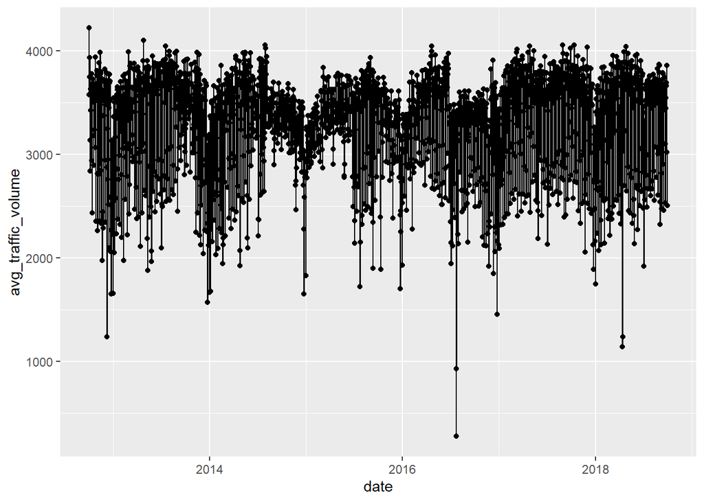

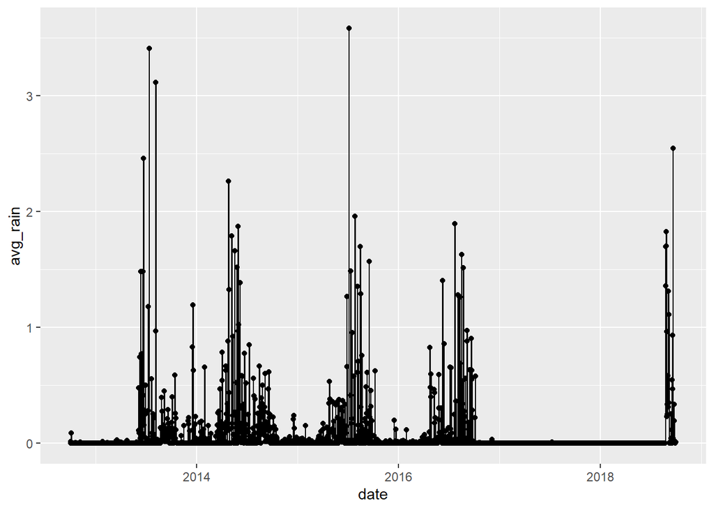

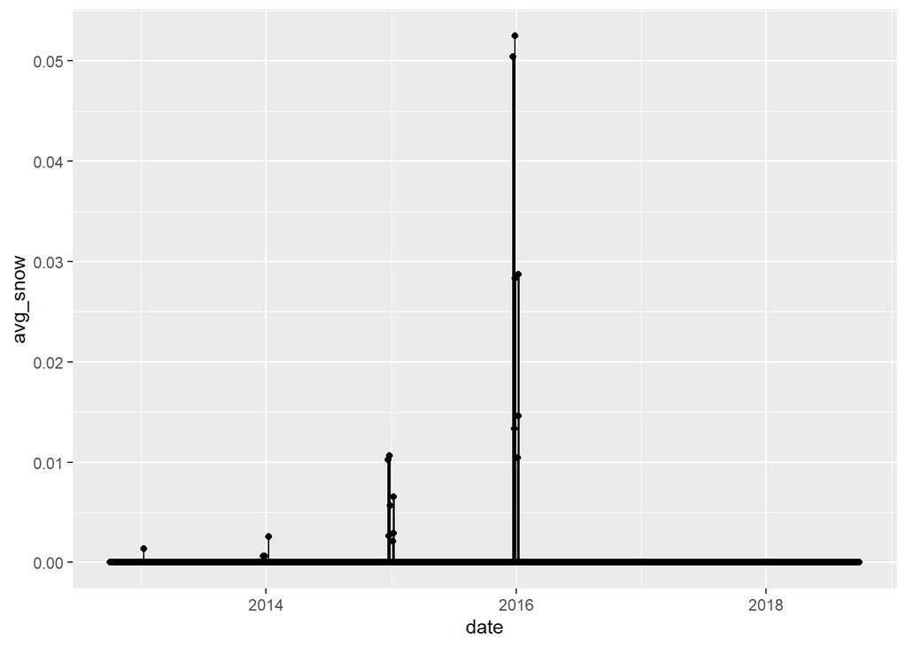

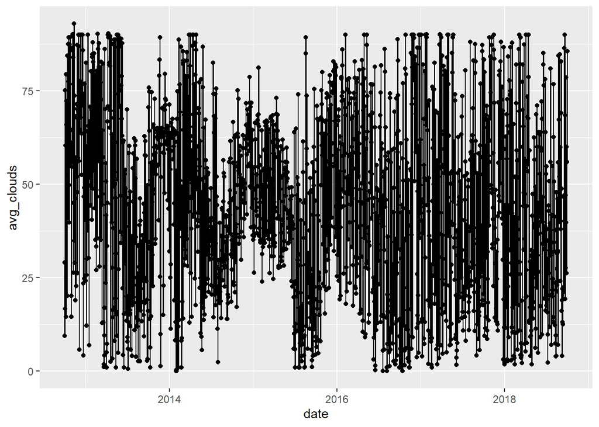

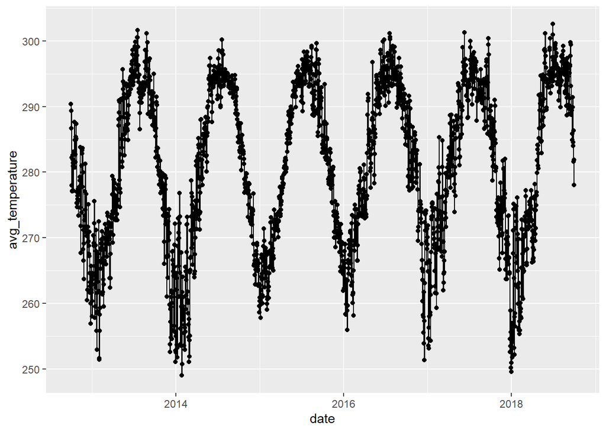

```r
for (col in rest_cols){
  x <- ggplot(data=df_avg, aes_string(x=date_col, y=col, group=1)) +
  geom_line()+
  geom_point()
  print(x)
}
```

Let’s look at the ACF plots.

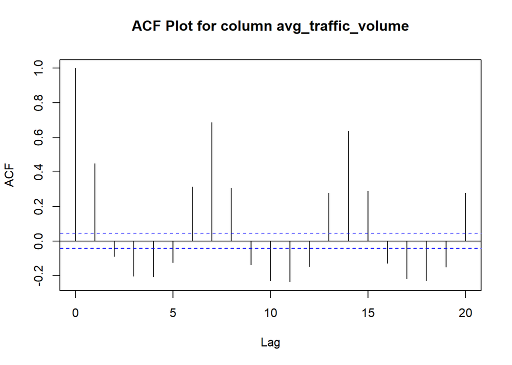

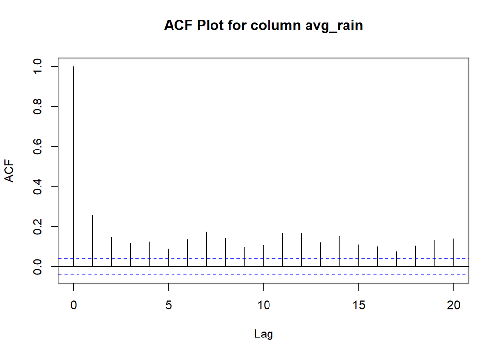

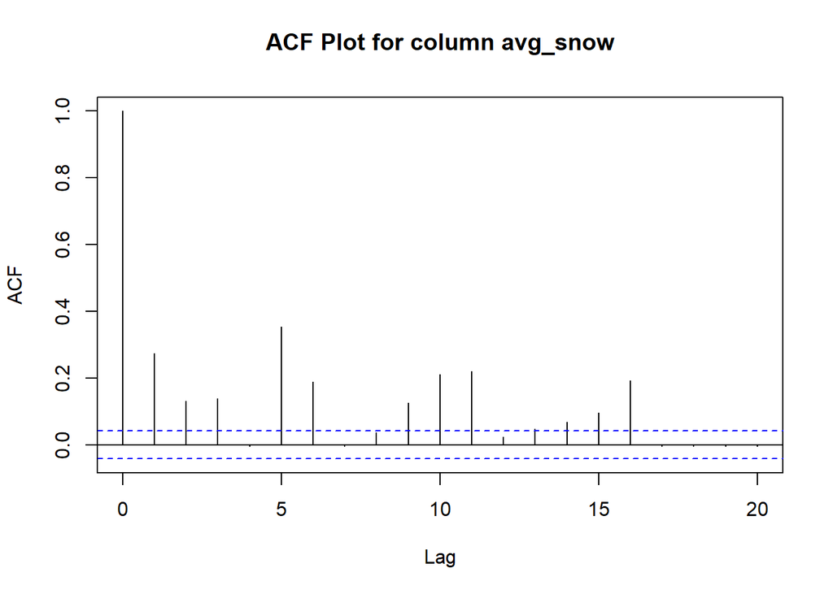

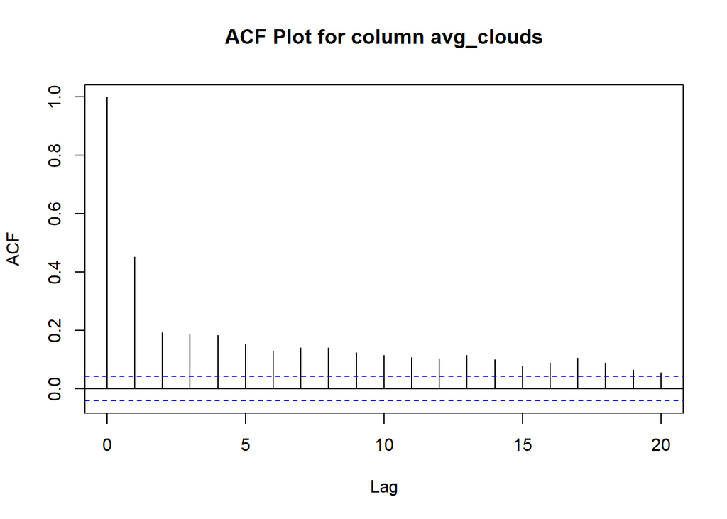

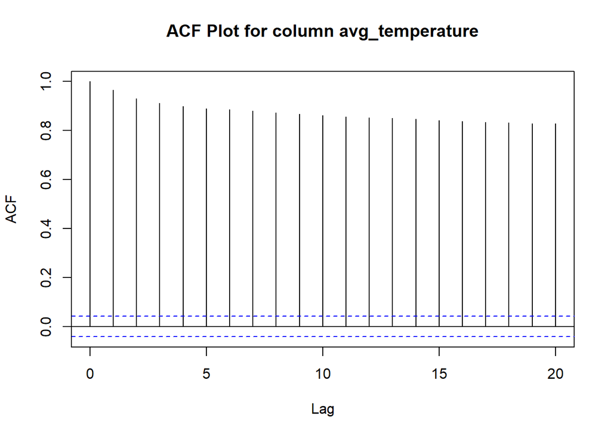

```r
for (col in rest_cols){
  acf_values = acf(df_avg[col], plot = FALSE, lag.max = 20)
  plot(acf_values, main = paste("ACF Plot for column", col))
}
```

ACF plot for traffic volume has a sinusoidal structure. This tells us that there is seasonality in the data, with period 7. Which makes sense that given that is a traffic data. This means the data is not stationary.  
Rain doesn’t have seasonality. Autocorrelation is at around 0.25 in lag 1.  
Snow doesn’t have seasonality.  
Clouds seem to have a steady decline in autocorrelation.  
Temperature data has a near constant autocorrelation. meaning that this value stays relatively constant over time.

Let’s repeat the process with a lag of 2 years.

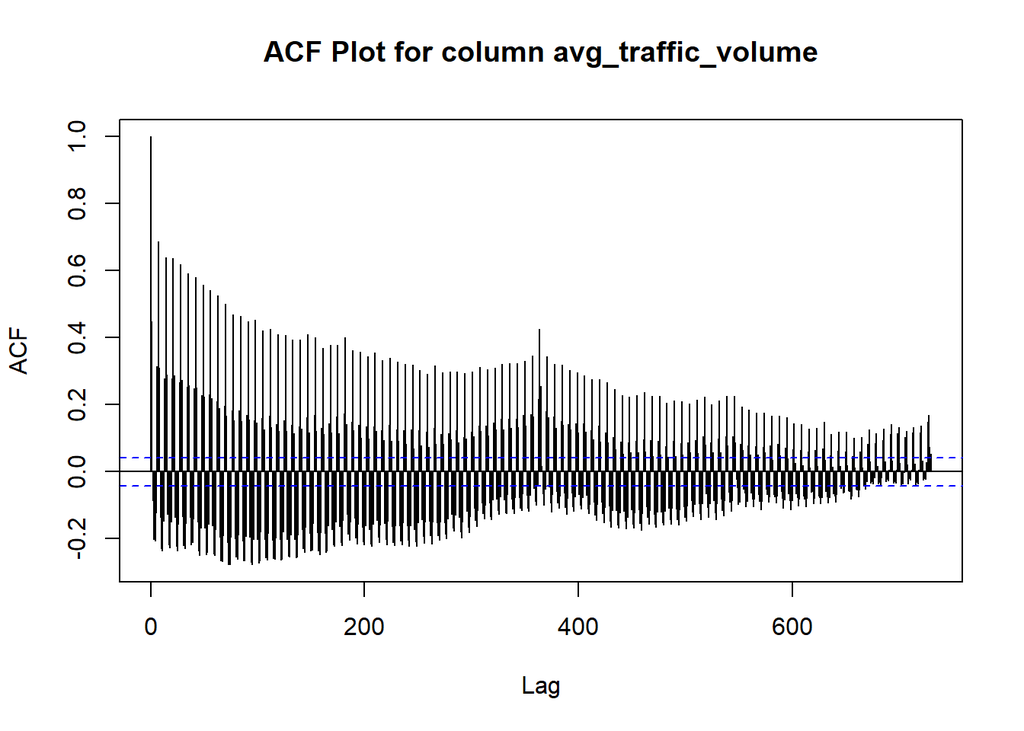

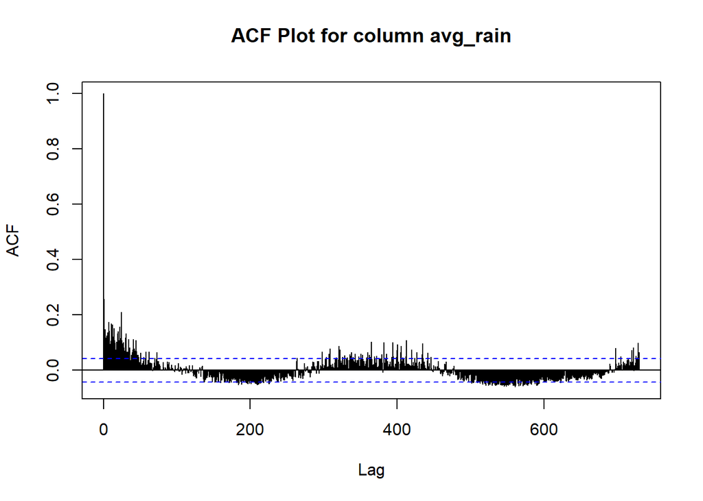

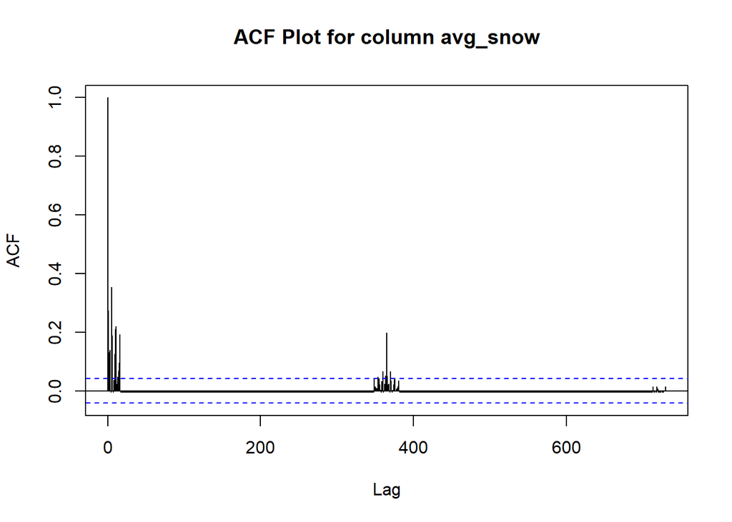

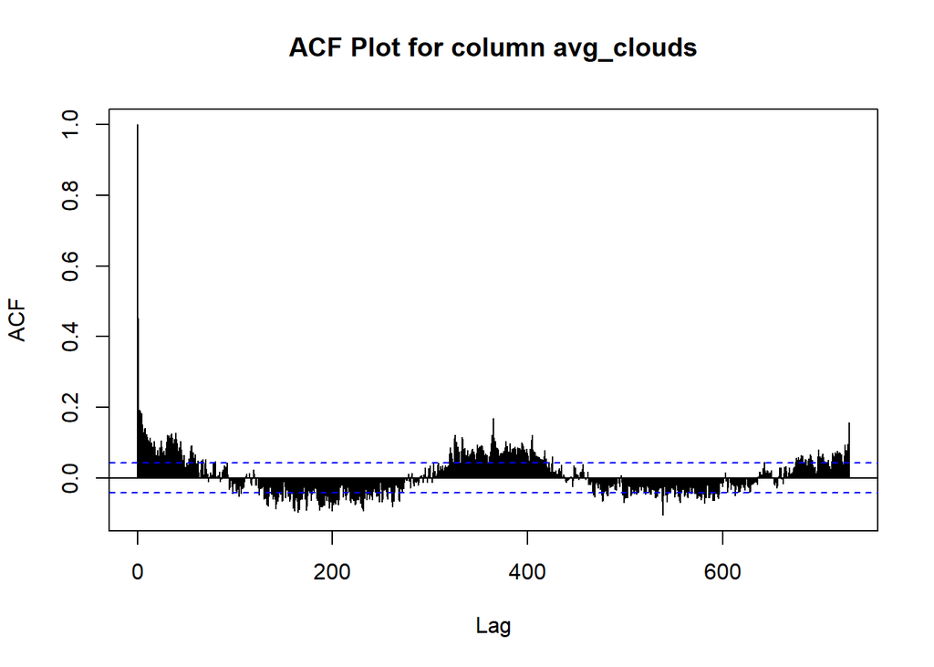

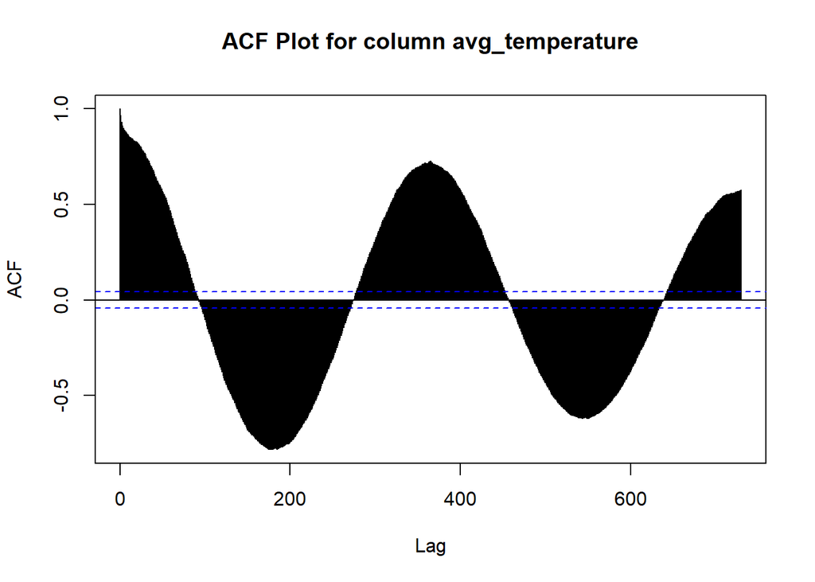

```r
for (col in rest_cols){
  acf_values = acf(df_avg[col], plot = FALSE, lag.max = 365*2)
  plot(acf_values, main = paste("ACF Plot for column", col))
}
```

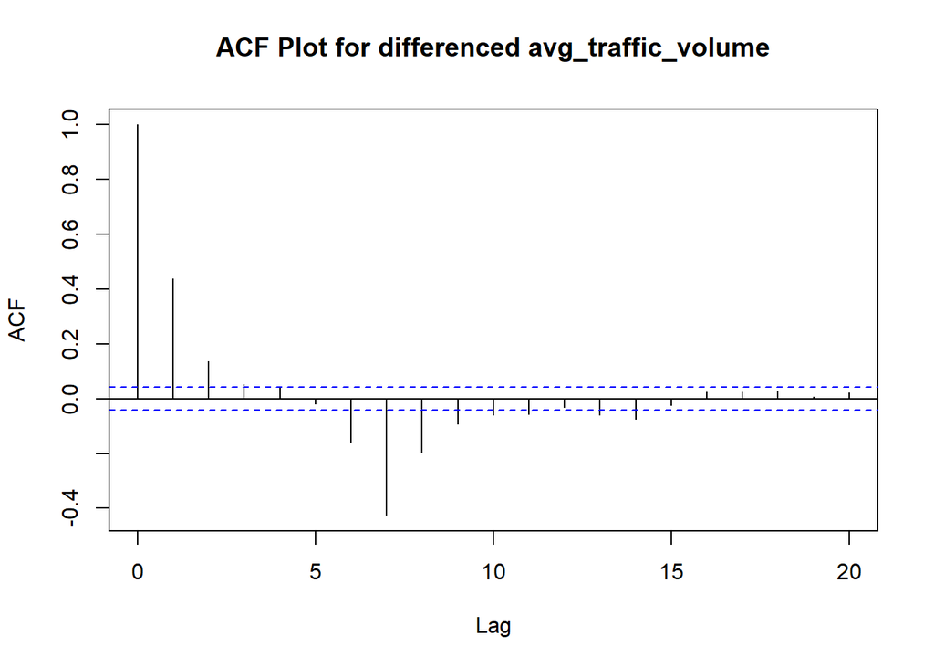

```r
x = diff(as.ts(df_avg['avg_traffic_volume'], frequency=7),lag=7, differences=1)
acf_values = acf(x, plot = FALSE, lag.max = 20)
plot(acf_values, main = paste("ACF Plot for differenced avg_traffic_volume"))
```

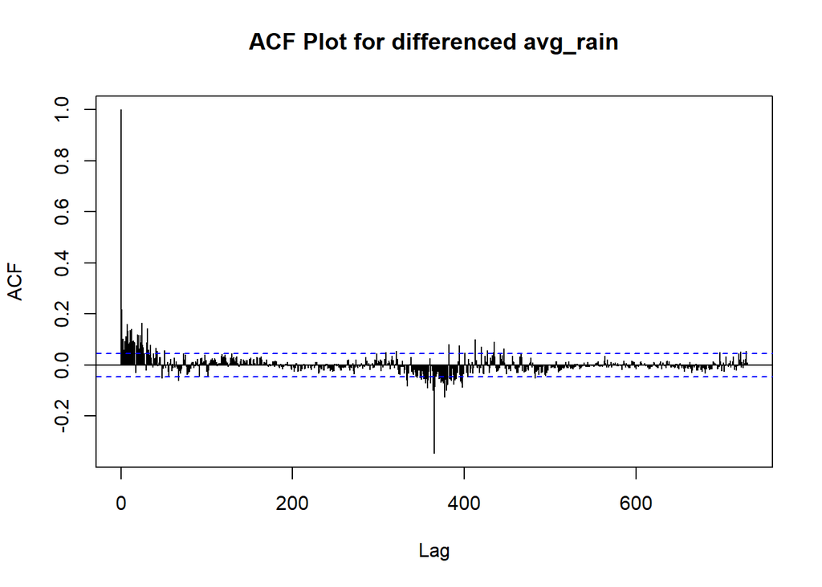

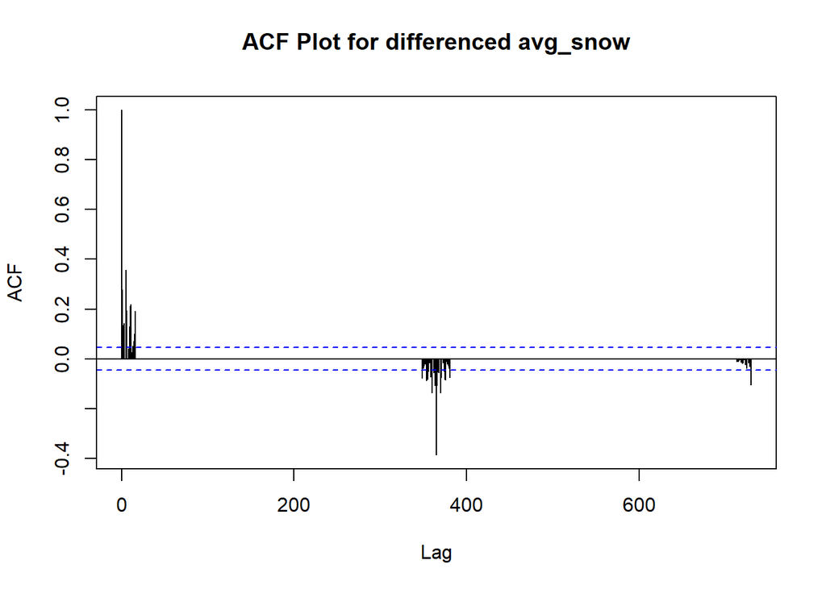

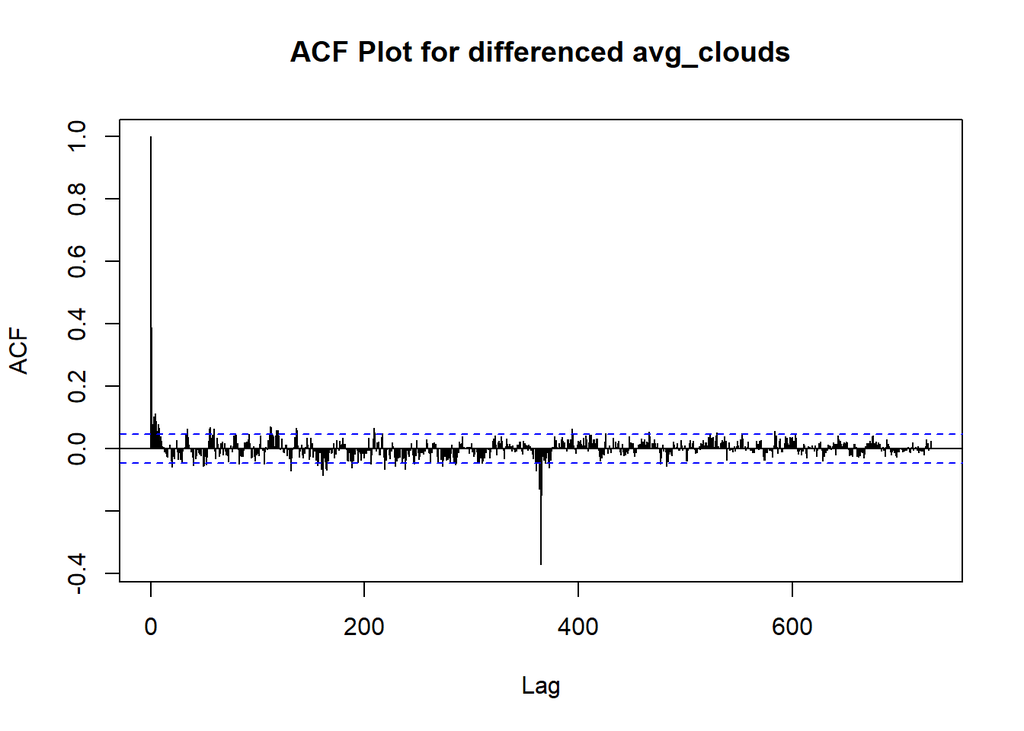

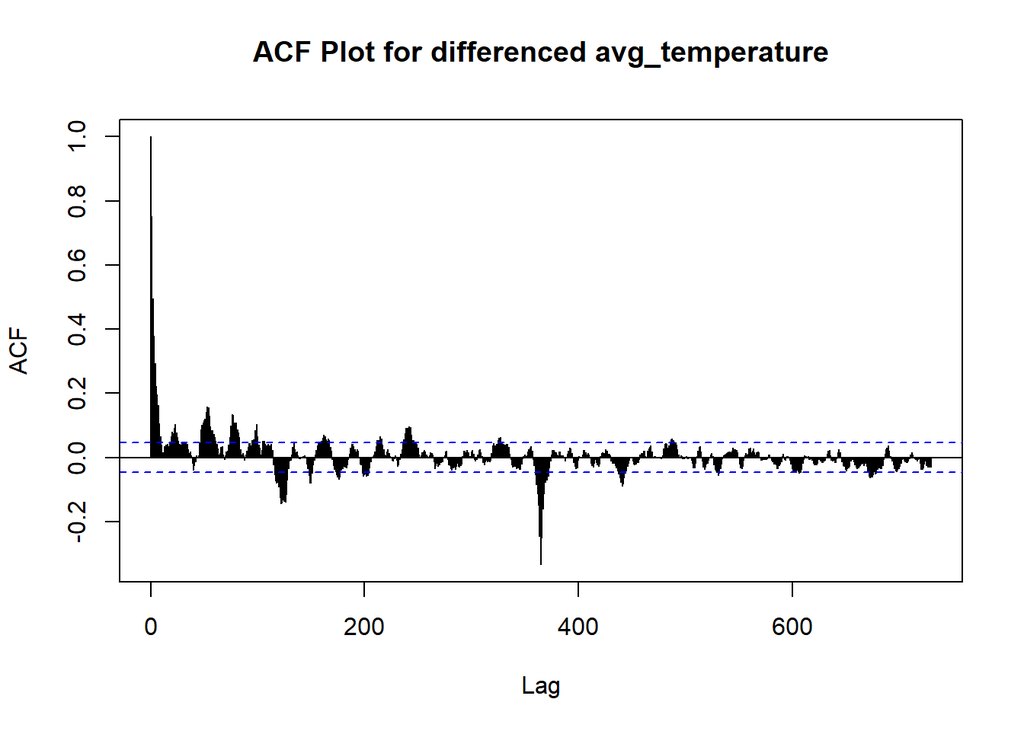

```r
for (col in rest_cols[-1]){
  x = diff(as.ts(df_avg[col], frequency=365),lag=365, differences=1)
  acf_values = acf(x, plot = FALSE, lag.max = 365*2)
  plot(acf_values, main = paste("ACF Plot for differenced", col))
}
```

The strong seasonality in the temperature data has been removed.

Let’s now look at the PACF values.

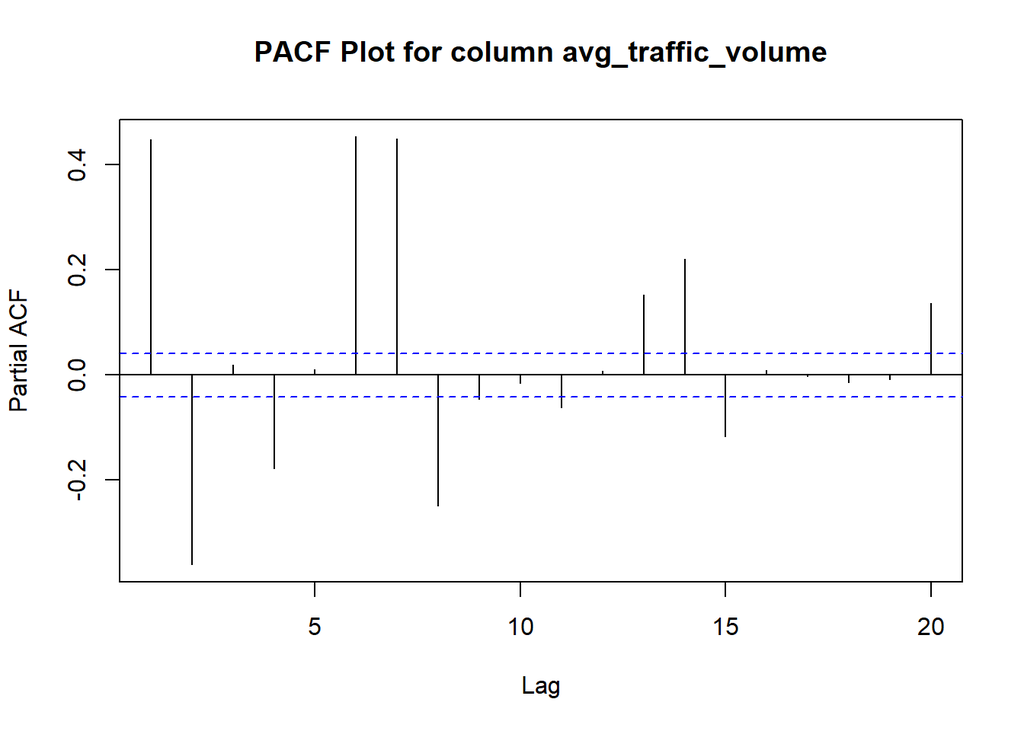

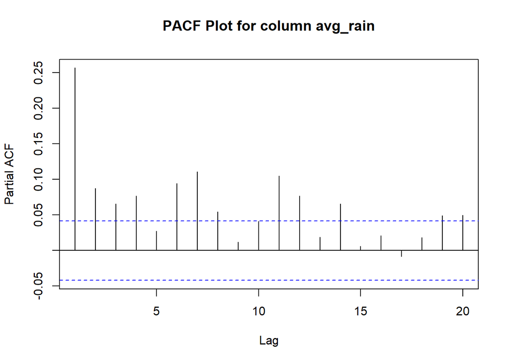

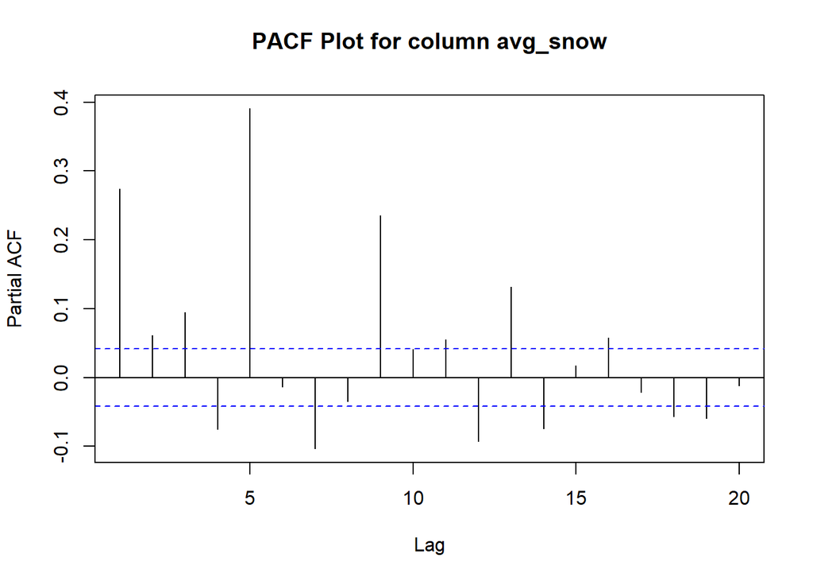

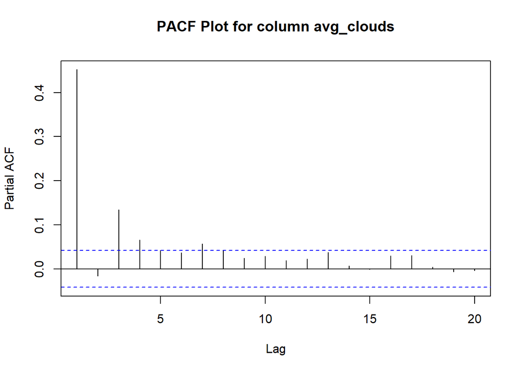

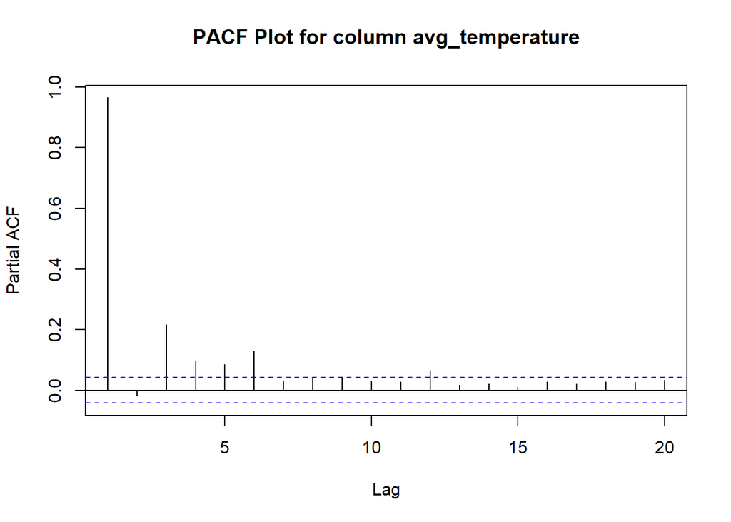

```r
for (col in rest_cols){
  pacf_values = pacf(as.ts(df_avg[col]), plot = FALSE, lag.max = 20)
  plot(pacf_values, main = paste("PACF Plot for column", col))
}
```

Let’s perform the KPSS tests.

```r
# KPSS test
for (col in rest_cols){
  print(col)
  print(kpss.test(as.ts(df_avg[col])))
}
```

```
## [1] "avg_traffic_volume"
```

```
##
##  KPSS Test for Level Stationarity
##
## data:  as.ts(df_avg[col])
## KPSS Level = 0.18525, Truncation lag parameter = 8, p-value = 0.1
##
## [1] "avg_rain"
```

```
##
##  KPSS Test for Level Stationarity
##
## data:  as.ts(df_avg[col])
## KPSS Level = 0.82221, Truncation lag parameter = 8, p-value = 0.01
##
## [1] "avg_snow"
```

```
##
##  KPSS Test for Level Stationarity
##
## data:  as.ts(df_avg[col])
## KPSS Level = 0.19681, Truncation lag parameter = 8, p-value = 0.1
##
## [1] "avg_clouds"
```

```
##
##  KPSS Test for Level Stationarity
##
## data:  as.ts(df_avg[col])
## KPSS Level = 1.1637, Truncation lag parameter = 8, p-value = 0.01
##
## [1] "avg_temperature"
##
##  KPSS Test for Level Stationarity
##
## data:  as.ts(df_avg[col])
## KPSS Level = 0.72695, Truncation lag parameter = 8, p-value = 0.0111
```

Rain, clouds and temperatures have trends according to the KPSS test. We need to perform differentiation on these values.

```r
kpss.test(diff(as.ts(df_avg['avg_rain']),1))
```

```
##
##  KPSS Test for Level Stationarity
##
## data:  diff(as.ts(df_avg["avg_rain"]), 1)
## KPSS Level = 0.0024239, Truncation lag parameter = 8, p-value = 0.1
```

A single differentiation is enough for the Rain data.

```r
kpss.test(diff(as.ts(df_avg['avg_clouds']),1))
```

```
##
##  KPSS Test for Level Stationarity
##
## data:  diff(as.ts(df_avg["avg_clouds"]), 1)
## KPSS Level = 0.0044317, Truncation lag parameter = 8, p-value = 0.1
```

A single differentiation is enough for the cloud data

```r
kpss.test(diff(as.ts(df_avg['avg_temperature']),1))
```

```
##
##  KPSS Test for Level Stationarity
##
## data:  diff(as.ts(df_avg["avg_temperature"]), 1)
## KPSS Level = 0.019864, Truncation lag parameter = 8, p-value = 0.1
```

A single differentiation is enough for the temperature data.

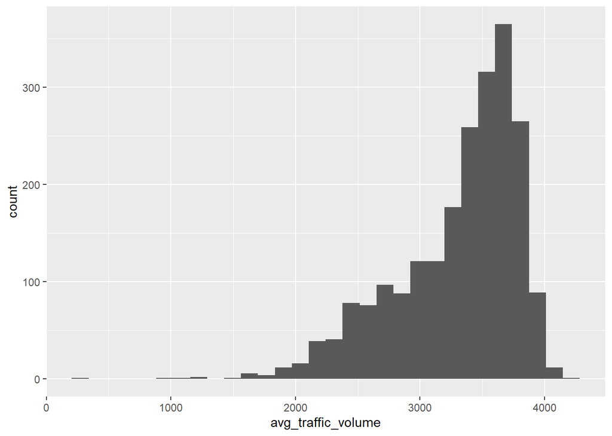

```r
ggplot(df_avg, aes(x = avg_traffic_volume)) + geom_histogram()
```

The data is skewed. A box-cox transformation could help.

```r
bc_transform.bN <- bestNormalize :: boxcox(df_avg$avg_traffic_volume, standardize = TRUE)
print(bc_transform.bN$lambda)
```

```
## [1] 1.999958
```

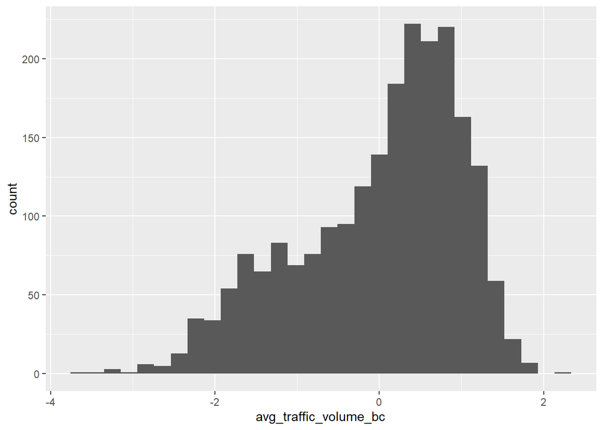

```r
df_avg$avg_traffic_volume_bc = bc_transform.bN$x.t
ggplot(df_avg, aes(x = avg_traffic_volume_bc)) + geom_histogram()
```

The data still seeme skewed. Let’s try the Yeo-Johnson transformation.

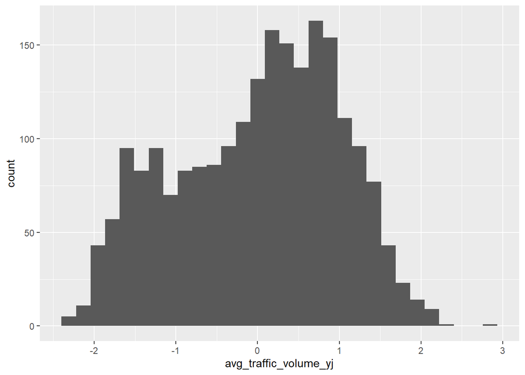

```r
yj_transform.bN <- bestNormalize :: yeojohnson(df_avg$avg_traffic_volume, standardize = TRUE)
df_avg$avg_traffic_volume_yj = yj_transform.bN$x.t
ggplot(df_avg, aes(x = avg_traffic_volume_yj)) + geom_histogram()
```

The data looks better with the Yeo-Johnson transformation.

```r
df_avg$avg_traffic_volume = df_avg$avg_traffic_volume_yj
```

Let’s also scale the other variables.

```r
df_avg[,c("avg_rain","avg_snow","avg_clouds","avg_temperature")]<- scale(df_avg[,c("avg_rain","avg_snow","avg_clouds","avg_temperature")])
```

## b)

Split the data into training and testing (training: 2013-14, testing: 2015) and train a (S)ARIMA model (without covariates) with auto.arima. Plot the forecast and compute the RMSE. Check the residuals and argue whether your model is a good choice for this type of data.

Restricting the data to 01.01.2013 - 31.12.2015

```r
df_filtered <- df_avg %>%
  filter(between(date, as.Date("2013-01-01"), as.Date("2015-12-31")))
```

Splitting the data into train and test

```r
df_train = df_filtered %>%
  filter(between(date, as.Date("2013-01-01"), as.Date("2014-12-31")))
df_test = df_filtered %>%
  filter(between(date, as.Date("2015-01-01"), as.Date("2015-12-31")))
```

```r
avg_traffic_volume.train = ts(df_train$avg_traffic_volume, frequency=365, start=c(2013,1))
avg_traffic_volume.test = ts(df_test$avg_traffic_volume, frequency=365, start=c(2015,1))
```

Training a model without the covariates.

```r
model_sarima_auto = auto.arima( ts(avg_traffic_volume.train, frequency=7))
```

```r
summary(model_sarima_auto)
```

```
## Series: ts(avg_traffic_volume.train, frequency = 7)
## ARIMA(2,0,0)(0,1,1)[7]
##
## Coefficients:
##          ar1      ar2     sma1
##       0.5217  -0.1253  -0.7816
## s.e.  0.0379   0.0372   0.0253
##
## sigma^2 = 0.3652:  log likelihood = -663.64
## AIC=1335.28   AICc=1335.33   BIC=1353.61
##
## Training set error measures:
##                       ME      RMSE       MAE      MPE     MAPE      MASE
## Training set 0.002854091 0.6001254 0.4254754 1.370813 235.0005 0.7559186
##                      ACF1
## Training set -0.003258057
```

We got a ARIMA(2,0,0)(0,1,1)[7] model.

```r
model_sarima = Arima(avg_traffic_volume.train,
                     order =c(2,0,0),
                     seasonal = list(order = c(0,1,1),
                                     period = 7))
```

```r
sarima_pred = forecast(model_sarima, h = 365)
```

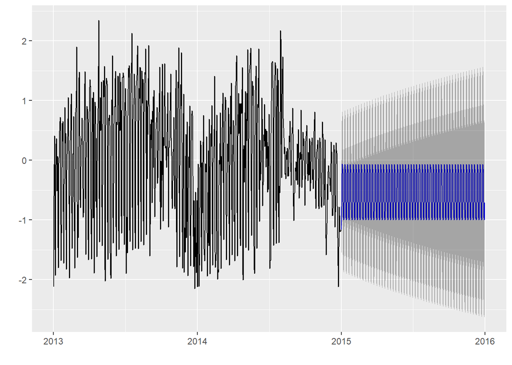

```r
sarima_pred %>% autoplot()
```

Let’s see how it compares to the test data.

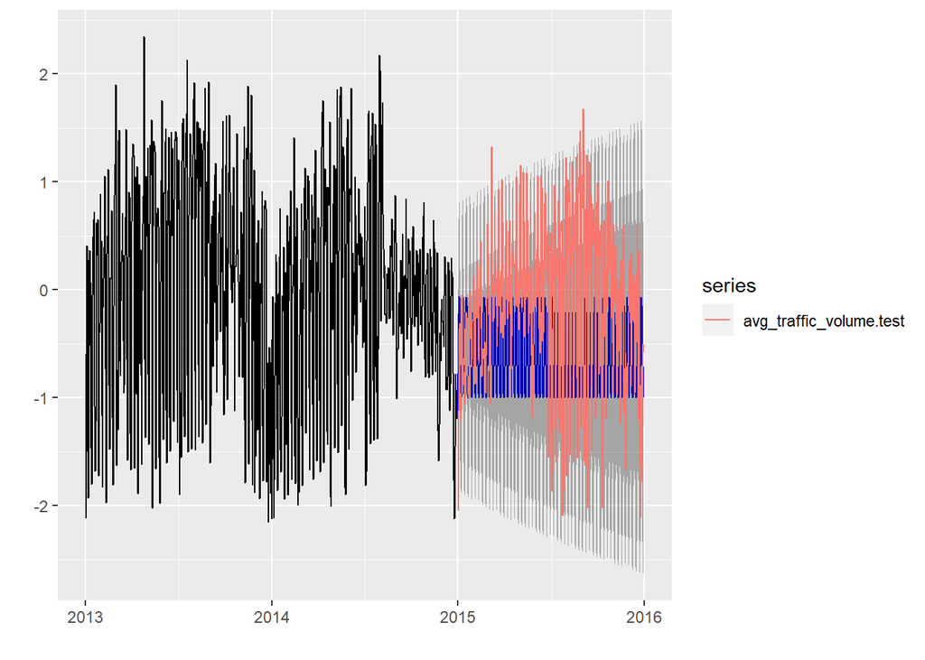

```r
sarima_pred %>% autoplot() + autolayer(avg_traffic_volume.test)
```

Calculating the RMSE

```r
rmse(ts(sarima_pred$mean), ts(avg_traffic_volume.test))
```

```
## [1] 0.9696305
```

Checking the residuals.

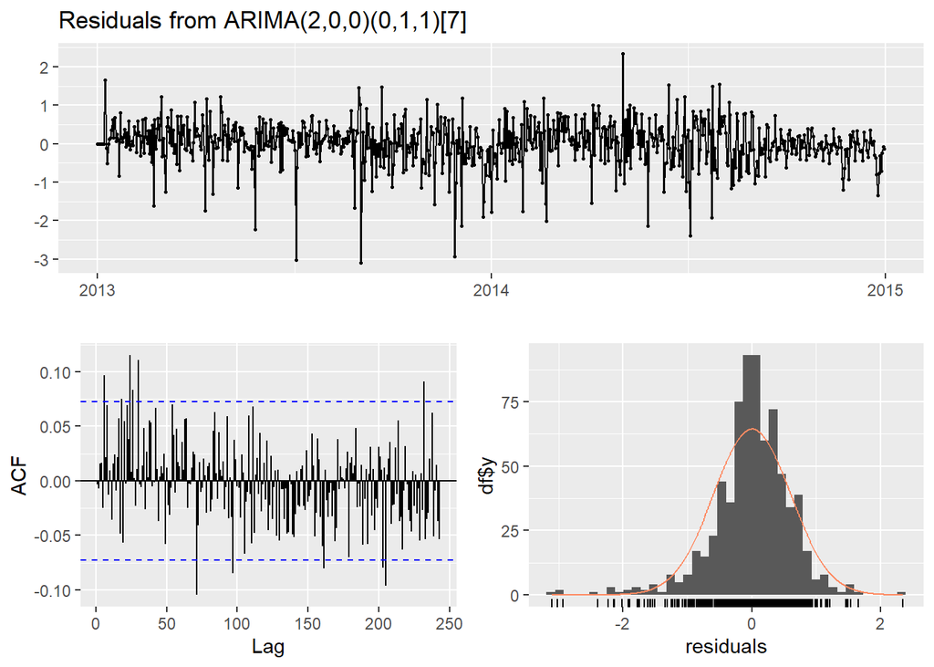

```
##
##  Ljung-Box test
##
## data:  Residuals from ARIMA(2,0,0)(0,1,1)[7]
## Q* = 165.91, df = 143, p-value = 0.09215
##
## Model df: 3.   Total lags used: 146
```

```r
checkresiduals(model_sarima)
```

Residuals are quite high. The model is not very good at capturing all information.

## c)

Train a (S)ARIMAX (dynamic regression) model with climate measurements as covariates. Plot the forecast and compute the RMSE.

```r
model_sarimax_auto = auto.arima(ts(avg_traffic_volume.train, frequency=7),
                              xreg = as.matrix(df_train[,c("avg_rain","avg_snow","avg_clouds","avg_temperature")])
                              )
```

```r
summary(model_sarimax_auto)
```

```
## Series: ts(avg_traffic_volume.train, frequency = 7)
## Regression with ARIMA(2,0,0)(0,1,1)[7] errors
##
## Coefficients:
##          ar1      ar2     sma1  avg_rain  avg_snow  avg_clouds  avg_temperature
##       0.4997  -0.1525  -0.8218   -0.0067   -0.0668     -0.0585           0.2047
## s.e.  0.0375   0.0379   0.0248    0.0183    0.0662      0.0250           0.0489
##
## sigma^2 = 0.3562:  log likelihood = -653.32
## AIC=1322.65   AICc=1322.85   BIC=1359.31
##
## Training set error measures:
##                       ME      RMSE       MAE      MPE     MAPE      MASE
## Training set 0.000831378 0.5911123 0.4205164 15.79373 223.0442 0.7471081
##                      ACF1
## Training set -0.006234735
```

```r
model_sarimax = Arima(avg_traffic_volume.train,
                      order = c(2,0,2),
                      seasonal = list(order = c(0,1,1), period = 7),
                      xreg = as.matrix(df_train[c("avg_rain","avg_snow","avg_clouds","avg_temperature")])
                      )
```

```r
sarimax_pred = forecast(model_sarimax,
                        h = 365,
                        xreg = as.matrix(df_test[c("avg_rain","avg_snow","avg_clouds","avg_temperature")])
                        )
```

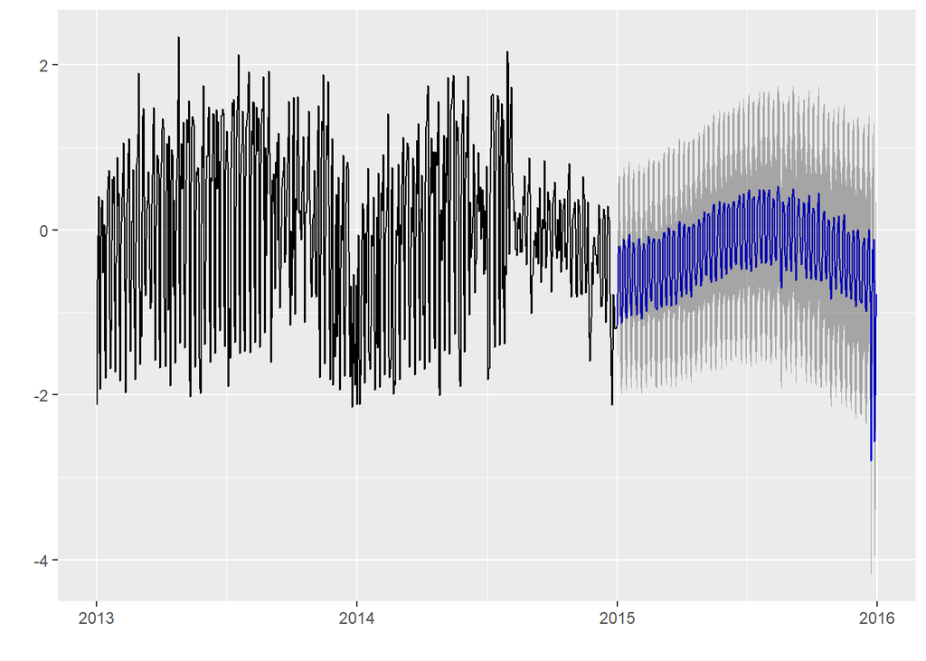

```r
sarimax_pred %>% autoplot()
```

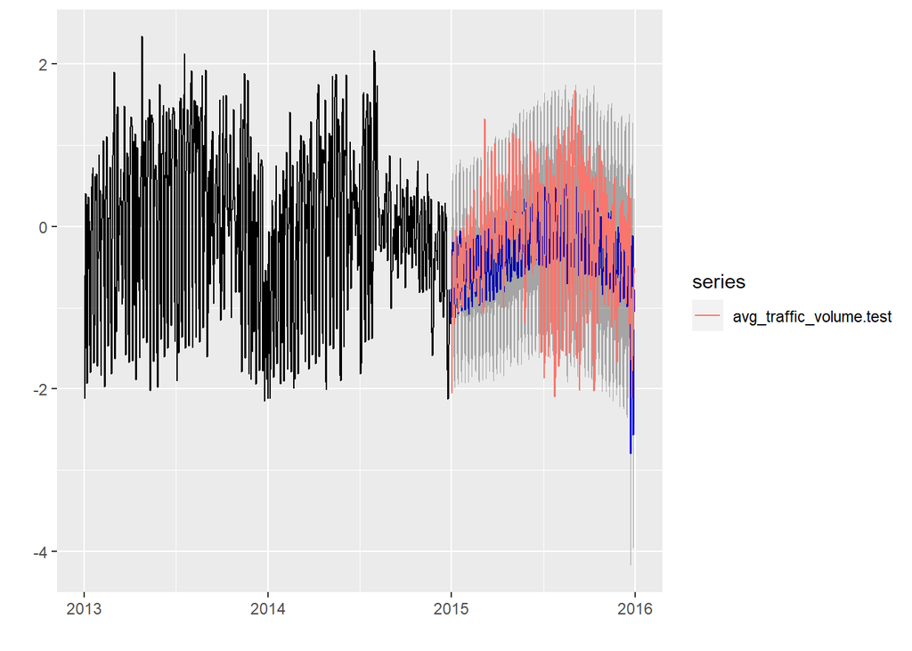

```r
sarimax_pred %>% autoplot() + autolayer(avg_traffic_volume.test)
```

Calculating the RMSE

```r
rmse(ts(sarimax_pred$mean), ts(avg_traffic_volume.test))
```

```
## [1] 0.8644731
```

Checking the residuals.

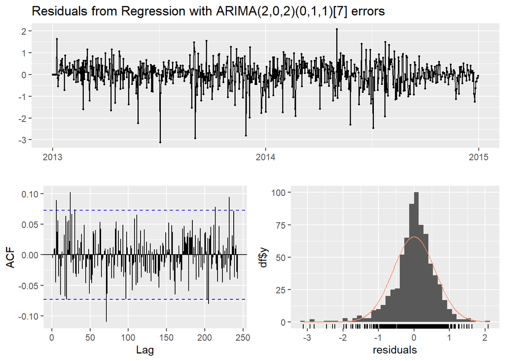

```
##
##  Ljung-Box test
##
## data:  Residuals from Regression with ARIMA(2,0,2)(0,1,1)[7] errors
## Q* = 139.92, df = 141, p-value = 0.5099
##
## Model df: 5.   Total lags used: 146
```

```r
checkresiduals(model_sarimax)
```

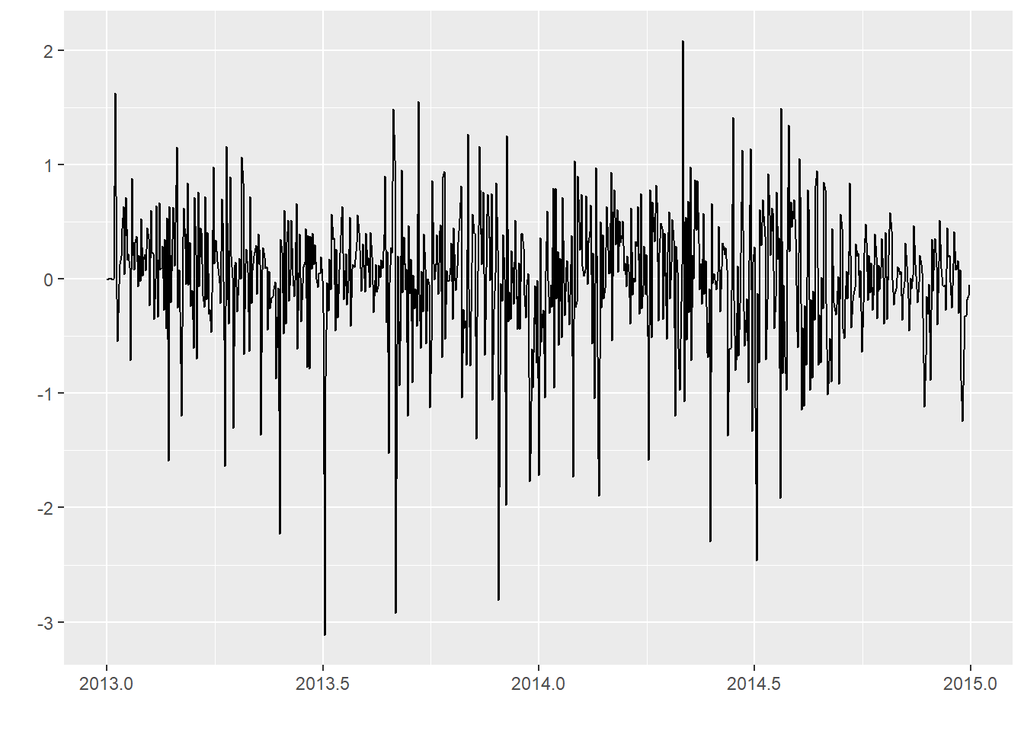

```r
model_sarimax$residuals %>% autoplot()
```

## d)

Compare the two models in (b) and (c). What are the benefits/drawbacks of taking covariates into account?

The RMSE of the SARIMA and SARIMAX model were 0.9696305 and 0.8644731 respectively. For a multivariate time series, the inclusion of the covariates gives us better performance as we have additional data to work with that influence our target variable. It also increases the model complexity by introducing additional terms during computation.

# Exercise 4

## a)

To simulate time series following an AR(2) or MA(2) model without intercept, consider the following instructions: - sample a vector Et of tmax i.i.d. errors from a Gaussian distribution (rnorm(n=t_max + 100, mean=0, sd=sigma)). Implement the given simulation procedure as an R function. Set a random seed (e.g., set.seed(10)) and use the function to simulate 3 time series for each model parameter combination specified in Tab. 2. Set the length of the time series to tmax = 1000 time points and the error standard deviation to σ = 0.1. Which of the parameter combinations in Tab. 2 describe proper AR(2) or MA(2) models?

```r
library(forecast)

sim_ar <- function(param){
  epsilon <- rnorm(n=1100, mean=0, sd=0.1)
  x <- epsilon[1:2]

  for(i in 3:length(epsilon)){
    x[i] <- t(param) %*% x[c(i-1, i-2)] + epsilon[i]
  }
  x <- x[-c(1:100)]
  return(ts(x))
}

sim_ma <- function(param){
  epsilon <- rnorm(n=1100, mean=0, sd=0.1)
  x <- epsilon[1:2]

  for(i in 3:length(epsilon)){
    x[i] <- t(param) %*% epsilon[c(i-1, i-2)] + epsilon[i]
  }
  x <- x[-c(1:100)]
  return(ts(x))
}

# simulate
set.seed(10)
param_list <- list(
  c(0.6, -0.3),
  c(0.8, 0.2))

s <- c()
for(phi in param_list){
  sim <- replicate(3, sim_ar(phi))
  s <- cbind(s, sim)
}
for(theta in param_list){
  sim <- replicate(3, sim_ma(theta))
  s <- cbind(s, sim)
}
names <- paste0(rep(c("AR","MA"), each = 2), 1:2)
colnames(s) <- paste(rep(names, each = 3), rep(1:3, 4), sep = ".")
```

All models except the AR(2) model with parameters (0.8,0.2) define stationary stochastic processes. In case of the AR(2) model with parameters (0.8,0.2), the side condition of AR model parameters, namely φ1+φ2<1, is violated, resulting non-stationary time series.

AR(2) with 0.8, 0.2 violates the side conditions stated for AR(2) models. To be stationary, it should satisfy all the following:

- $\Theta_{1} + \Theta_{2} < 1$
- $\Theta_{1} - \Theta_{2} < 1$
- $|\Theta_{2}| < 1$

So, the first combination (0.6, -0.3) for AR(2) describe proper AR(2) model because it validates all the condition.

## b)

Plot and compare all time series simulated in (a), as well as their ACFs and PACFs. Perform a KPSS tests - are the time series stationary?

KPSS test : if p-value is < significance level (0.05), then the series is non-stationary. ACF and PACF assume stationary of the underlying time series. For a stationary time series, the ACF will drop to zero relatively quickly, while the ACF of non-stationary data decreases slowly.

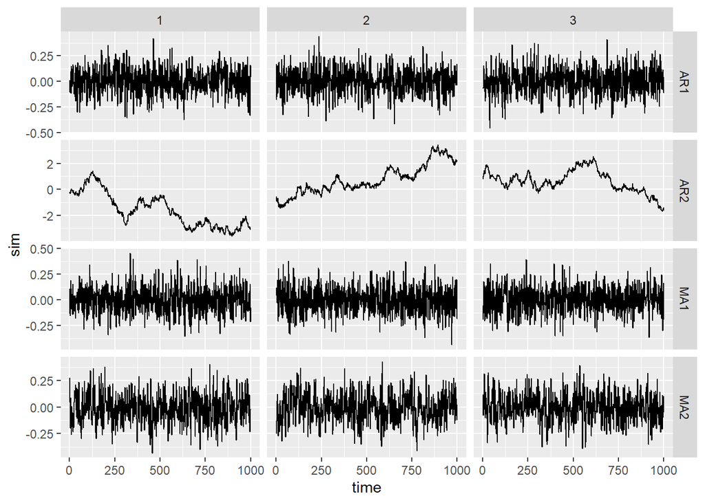

```r
library(tseries)

s %>% as.data.frame() %>%
      reshape(direction = "long", varying = list(1:3,4:6,7:9,10:12), v.names = names, timevar = "rep", idvar = "time") %>%
      reshape(direction = "long", varying = 2:5, v.names = "sim", timevar = "setup", times = names, idvar = c("rep", "time")) %>%
      ggplot(aes(x = time, y = sim)) + geom_line() + facet_grid(setup ~ rep, scales = "free_y")
```

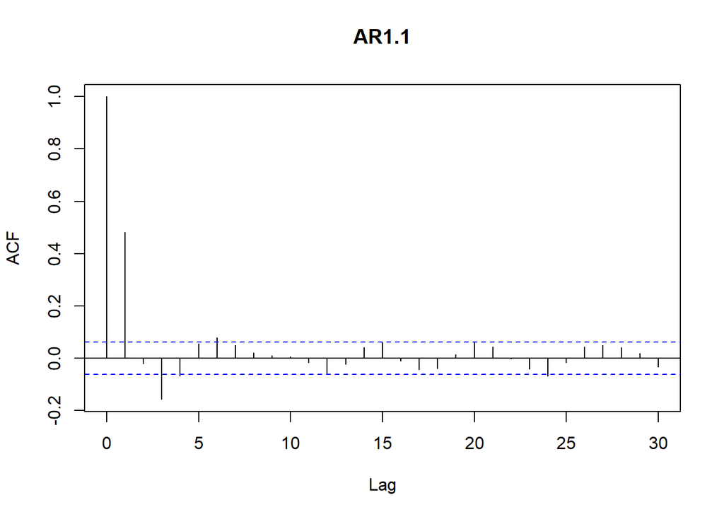

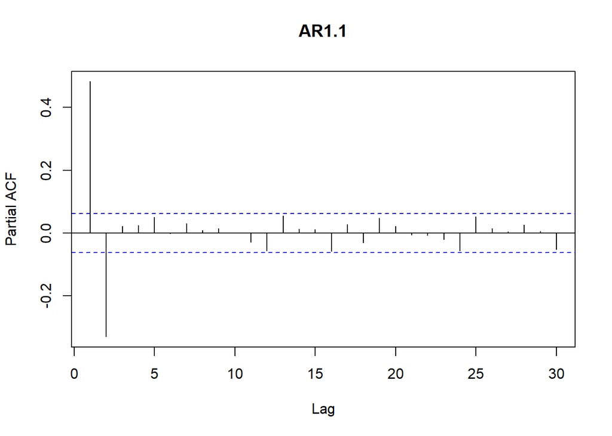

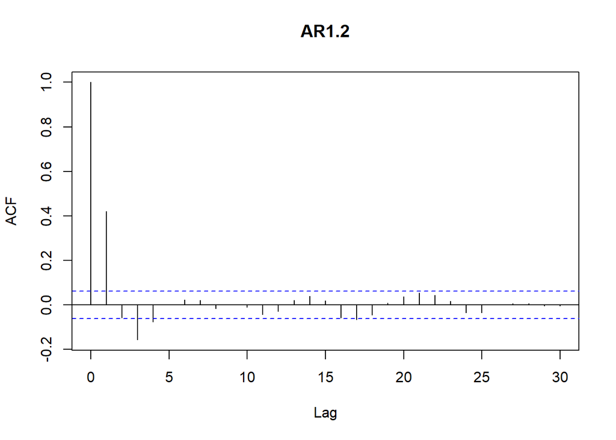

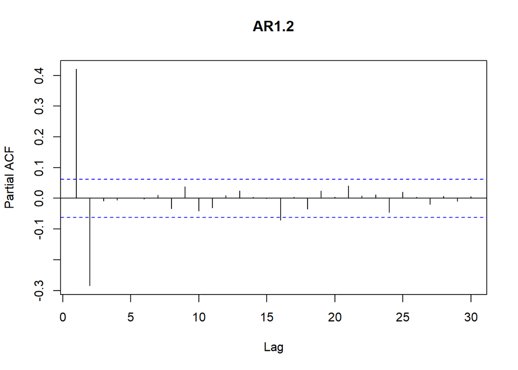

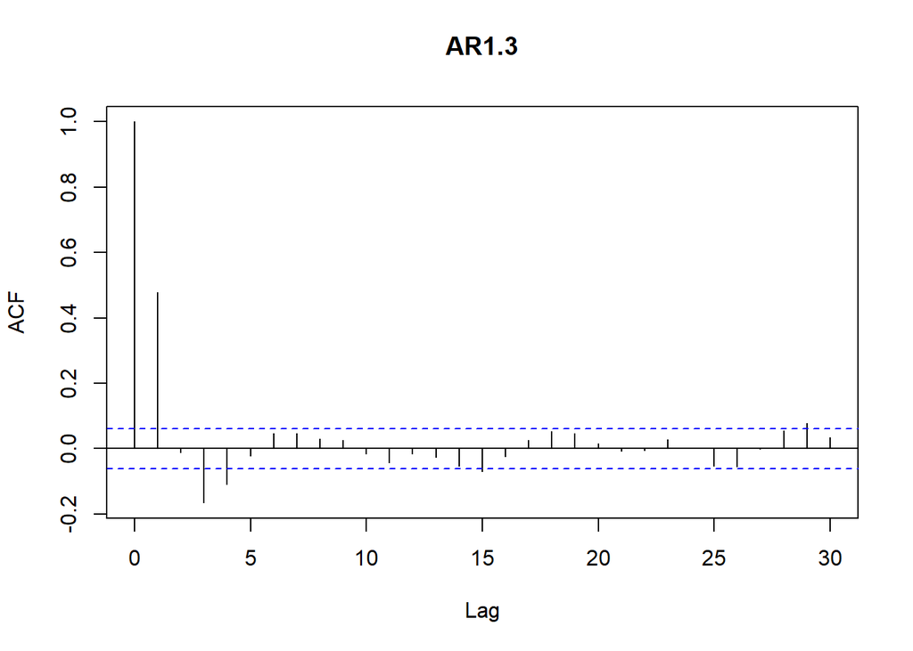

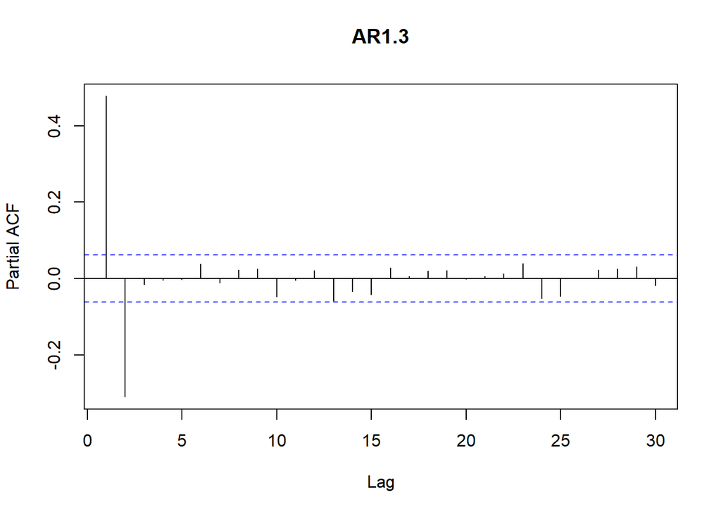

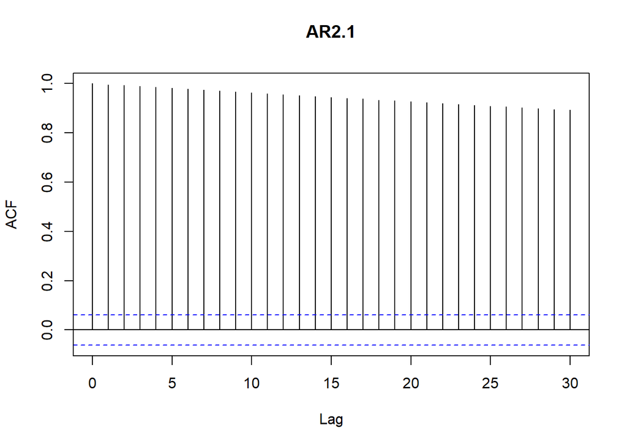

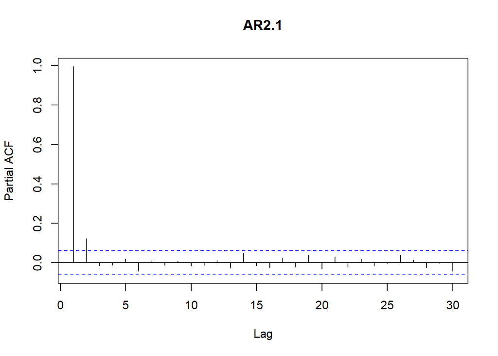

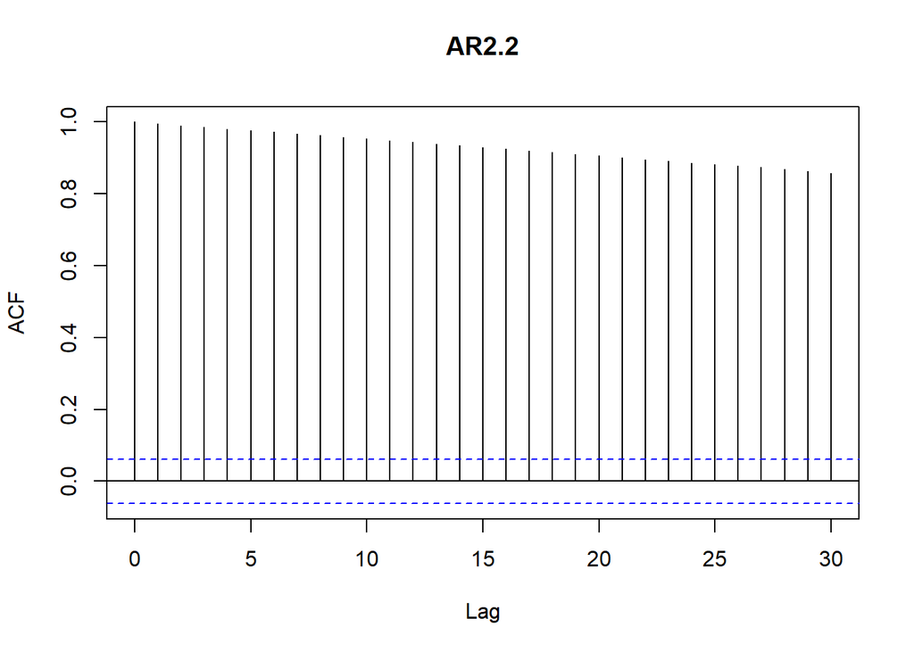

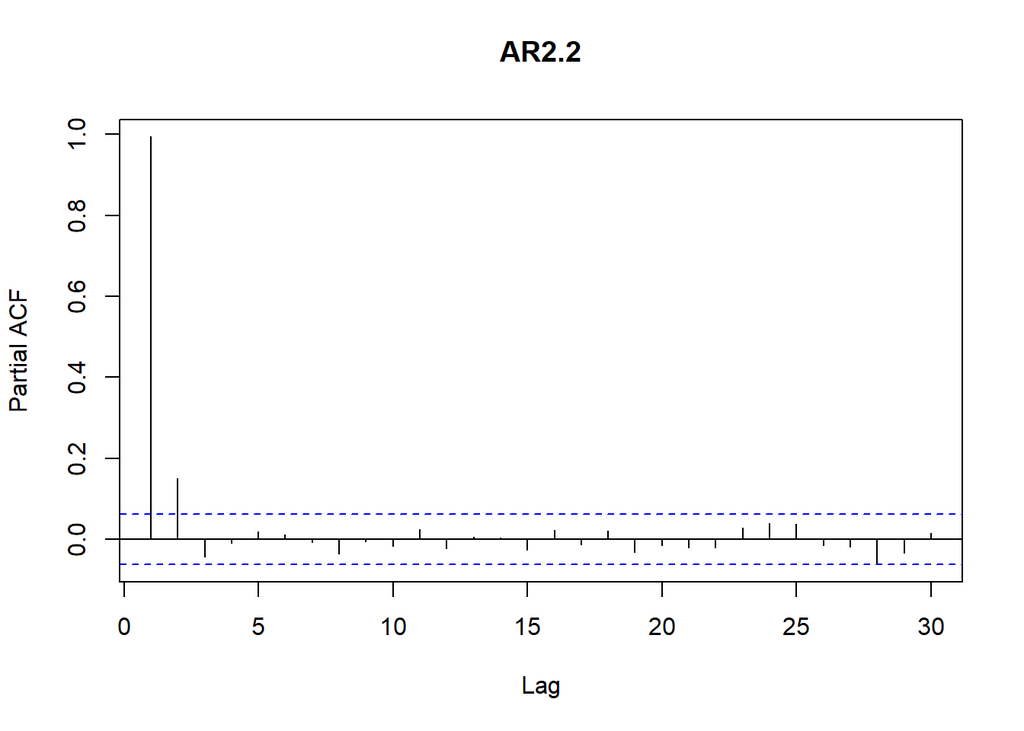

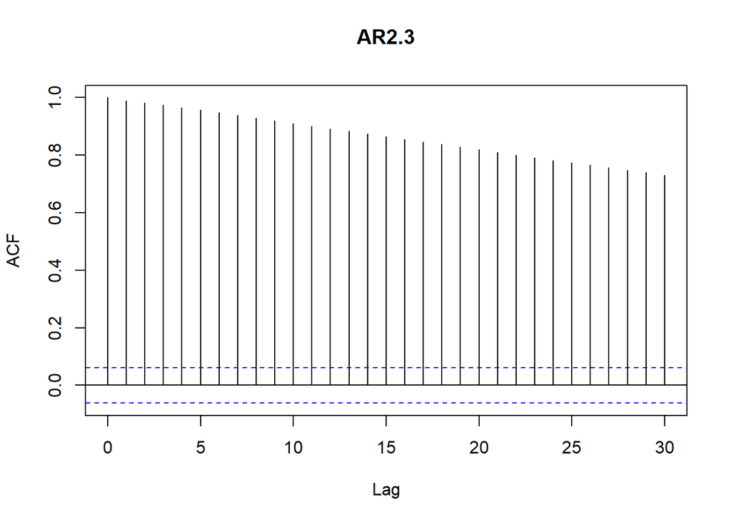

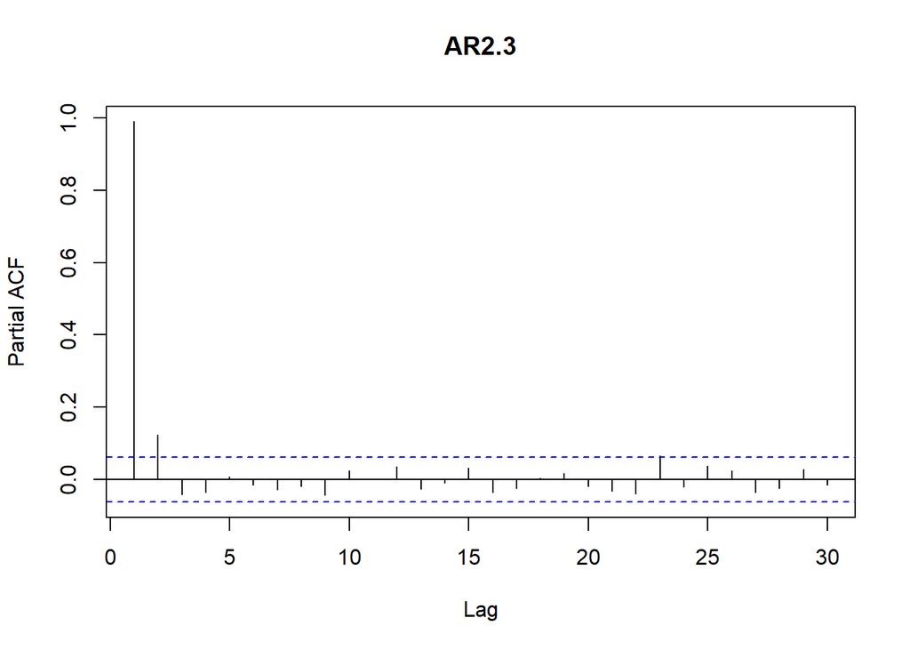

[12 more figures not shown]

```r
for(i in 1:ncol(s)){
  acf(s[,i], main=colnames(s)[i])
  pacf(s[,i], main=colnames(s)[i])
}
```

```r
apply(s, 2, kpss.test)
```

```
## $AR1.1
##
##  KPSS Test for Level Stationarity
##
## data:  newX[, i]
## KPSS Level = 0.074849, Truncation lag parameter = 7, p-value = 0.1
##
##
## $AR1.2
##
##  KPSS Test for Level Stationarity
##
## data:  newX[, i]
## KPSS Level = 0.16849, Truncation lag parameter = 7, p-value = 0.1
##
##
## $AR1.3
##
##  KPSS Test for Level Stationarity
##
## data:  newX[, i]
## KPSS Level = 0.12375, Truncation lag parameter = 7, p-value = 0.1
##
##
## $AR2.1
##
##  KPSS Test for Level Stationarity
##
## data:  newX[, i]
## KPSS Level = 9.568, Truncation lag parameter = 7, p-value = 0.01
##
##
## $AR2.2
##
##  KPSS Test for Level Stationarity
##
## data:  newX[, i]
## KPSS Level = 10.271, Truncation lag parameter = 7, p-value = 0.01
##
##
```

[output cut: 39 more lines]

```
##
## $MA2.2
##
##  KPSS Test for Level Stationarity
##
## data:  newX[, i]
## KPSS Level = 0.12218, Truncation lag parameter = 7, p-value = 0.1
##
##
## $MA2.3
##
##  KPSS Test for Level Stationarity
##
## data:  newX[, i]
## KPSS Level = 0.097168, Truncation lag parameter = 7, p-value = 0.1
```

The KPSS test underlines that samples from the ARIMA process with the second parameter combination violate the stationary assumption.

## c)

For all time series simulated in (a), fit the parameters of an ARIMA model using auto.arima (package forecast). Compare the estimated model parameters to the ground truth parameters. Which model parameter combinations can be restored?

```r
arima_models <- apply(s, 2, auto.arima)
gt_param_list <- rep(rep(param_list, each = 3), 2)

for(i in 1:length(arima_models)){
  pred_param <- arima_models[[i]]$coef
  gt_param <- gt_param_list[[i]]
  if(i <= 6){
    names(gt_param) <- paste0("ar", 1:2)
  }
  else{
    names(gt_param) <- paste0("ma", 1:2)
  }

  res <- bind_rows(pred_param, gt_param) %>%
    mutate(type = c("prediction", "gt")) %>%
    replace(is.na(.), 0)
  print(res)
}
```

```
## # A tibble: 2 × 3
##     ar1    ar2 type
##   <dbl>  <dbl> <chr>
## 1 0.641 -0.330 prediction
## 2 0.6   -0.3   gt
## # A tibble: 2 × 3
##     ar1    ar2 type
##   <dbl>  <dbl> <chr>
## 1 0.543 -0.288 prediction
## 2 0.6   -0.3   gt
## # A tibble: 2 × 3
##     ar1    ar2 type
##   <dbl>  <dbl> <chr>
## 1 0.625 -0.309 prediction
## 2 0.6   -0.3   gt
## # A tibble: 2 × 3
##      ar1   ar2 type
##    <dbl> <dbl> <chr>
## 1 -0.175   0   prediction
## 2  0.8     0.2 gt
## # A tibble: 2 × 3
##      ar1    ar2 type
##    <dbl>  <dbl> <chr>
## 1 -0.198 0.0111 prediction
## 2  0.8   0.2    gt
## # A tibble: 2 × 4
##     ar1   ar2    ma1 type
##   <dbl> <dbl>  <dbl> <chr>
## 1 0.552 0.180 -0.751 prediction
## 2 0.8   0.2    0     gt
## # A tibble: 2 × 5
##      ar1     ar2   ma1   ma2 type
##    <dbl>   <dbl> <dbl> <dbl> <chr>
## 1 -0.304 -0.0596 0.951   0   prediction
## 2  0      0      0.6    -0.3 gt
## # A tibble: 2 × 5
##     ar1    ma1    ma2   ma3 type
##   <dbl>  <dbl>  <dbl> <dbl> <chr>
## 1 0.908 -0.308 -0.854 0.265 prediction
## 2 0      0.6   -0.3   0     gt
## # A tibble: 2 × 5
##      ar1   ma1    ma2 intercept type
##    <dbl> <dbl>  <dbl>     <dbl> <chr>
## 1 0.0625 0.524 -0.348   0.00549 prediction
## 2 0      0.6   -0.3     0       gt
## # A tibble: 2 × 6
##     ar1     ar2   ma1 intercept   ma2 type
##   <dbl>   <dbl> <dbl>     <dbl> <dbl> <chr>
## 1 0.424 -0.0968 0.356   -0.0107   0   prediction
## 2 0      0      0.8      0        0.2 gt
## # A tibble: 2 × 5
##     ar1    ar2   ma1   ma2 type
##   <dbl>  <dbl> <dbl> <dbl> <chr>
## 1 0.265 0.0242 0.558   0   prediction
## 2 0     0      0.8     0.2 gt
## # A tibble: 2 × 4
##     ar1   ma1   ma2 type
##   <dbl> <dbl> <dbl> <chr>
## 1 0.286 0.487   0   prediction
## 2 0     0.8     0.2 gt
```

In general, the estimated parameters of stationary AR(2) samples are very close to the true parameters. For MA(2) samples, restoring ground truth values (and hyperparameters) is less accurate. Estimation of additional AR or MA terms (in particular for MA(2) samples) might be due to local optima in the discrete optimization procedure.

## d)

One parameter combination in Tab. 2 obviously violates the side conditions stated for AR(2) models. Show that first-order differences lead to a proper AR(2) model (i.e. fulfill the side conditions).

AR(2) with 0.8, 0.2 violates the side conditions stated for AR(2) models. To be stationary, it should satisfy all the following:

- $\Theta_{1} + \Theta_{2} < 1$
- $\Theta_{1} - \Theta_{2} < 1$
- $|\Theta_{2}| < 1$

Another way:

Let φ1=0.8,φ2=0.2∈R be arbitrary coefficients of AR(2). The model is given as xt=φ1xt−1+φ2xt−2+εt.

Applying a difference operator D leads to D(xt)=xt−xt−1=φ1xt−1+φ2xt−2−xt−1+εt=(φ1−1)xt−1+φ2xt−2+εt=φ1~xt−1+φ2xt−2+εt

Thus, the differenced time series is an AR(2) model with parameters φ~1=φ1−1=−0.2 and φ2~=φ2=0.2, which fulfills the stated side conditions:

|φ~2|=0.2<1 (φ<sub>1+φ</sub>2)=(−0.2+0.2)=0<1 (φ<sub>2−φ1</sub>)=(0.2+0.2)=0.4<1